# Netflix & Dow Jones 2017

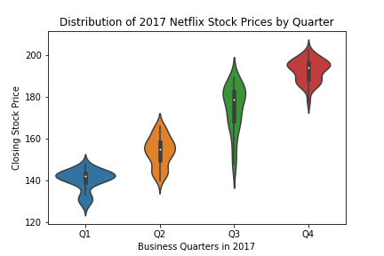

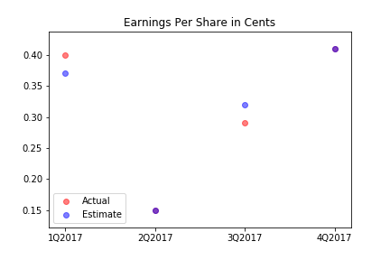

My first impressions are: 1) The stock price had been trending higher throughout the year of 2017, from range of 140 per share in Q1 to range of 200 per share in Q4. 2) The stock price had shown a very strong volatility in Q3, a fat tail characterastic. The price was down to 140/share in a very short time window before trending higher to 200 in Q4. And it probably worth a closer examination of the cause of such strong volatility. Is it because of the systematic risk (entire market was volatile at that time) or because of the idiosyncratic risk (only netflix showed a volatility in price movement).

When we compare the stock price distribution by quarter with the difference in actual and estimate earnings plot below it, we can see that in the third quarter, the actual earnings missed the estimate earning by a lot, which might be a reason why the stock price dropped sharply in the thrid quarter as we observed in the stock price distribution chart. However, we need to examine more closely and compare the date before making any conclusion.

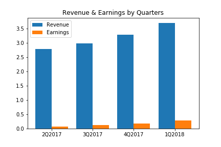

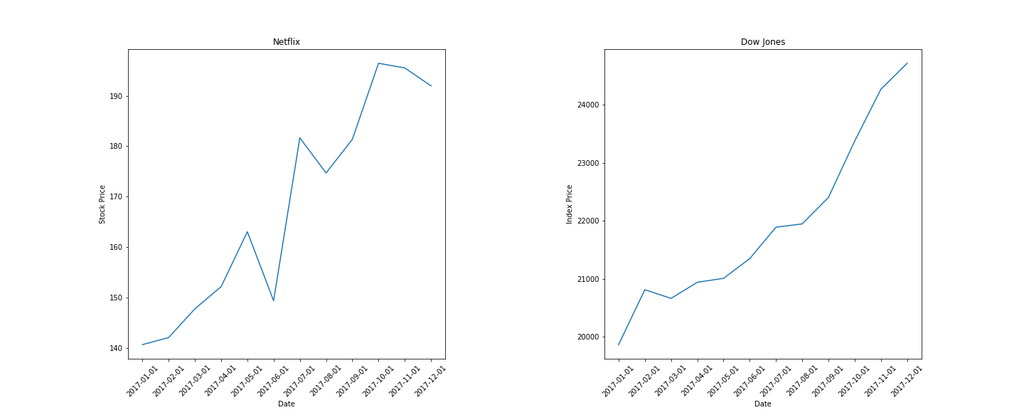